# **A Kernel-based Consensual Aggregation for Regression -** [Has (2021)](https://hal.archives-ouvertes.fr/hal-02884333v5)

Sothea Has

3/28/2022

> **✎ Note**: All codes contained in this `Rmarkdown` are built with recent version of (version $>$ 4.1, available [here](https://cran.r-project.org/bin/windows/base/)) and **Rstudio** (version > `2022.02.2+485`, available [here](https://www.rstudio.com/products/rstudio/download/#download)). Note also that the code chucks are hidden by default.

**To see the codes, you can:**

- click on the top-right `Code` button of the page, then choose **Show All Code** to show all the codes, or
- simply click on the right-corner `Code` button at each section to show the codes of that specific section.

# 1 Consensual aggregation & important packages

## 1.1 Consensual aggregation

This `Rmarkdown` provides the implementation of consensual aggregation method by [Has (2021)](https://hal.archives-ouvertes.fr/hal-02884333v5). Let $\mathcal{D}_n=\{(x_1,y_1),...,(x_n,y_n)\}$ be a training data of size $n$, where the input-output couples $(x_i,y_i)\in\mathbb{R}^d\times\mathbb{R}$ for all $i=1,...,n$. $\mathcal{D}_{n}$ is first randomly partitioned into $\mathcal{D}_{k}$ and $\mathcal{D}_{\ell}$ of size $k$ and $\ell$ respectively such that $k+\ell=n$. We construct $M$ regression estimators (machines) $r_1,...,r_M$ using only $\mathcal{D}_{k}$. Let ${\bf r}(x)=(r_1(x),...,r_M(x))^T\in\mathbb{R}^M$ be the vector of predictions of $x\in\mathbb{R}^d$, the kernel-based consensual aggregation method evaluated at point $x$ is defined by

$$\begin{equation}
g_n({\bf r}(x))=\frac{\sum_{i=1}^{\ell}y_iK_h({\bf r}(x)-{\bf
r}(x_i))}{\sum_{j=1}^{\ell}K_h({\bf r}(x)-{\bf r}(x_j))}
\end{equation}$$
where $K:\mathbb{R}^M\to\mathbb{R}_+$ is a non-increasing kernel function with $K_h(x)=K(x/h)$ for some smoothing parameter $h>0$ to be tuned, with the convention $0/0=0$. Even though the formula of $g_n$ is defined using only data points in $\mathcal{D}_{\ell}$, it does depend on the whole training data $\mathcal{D}_{n}$ as the basic machines $(r_i)_{i=1}^M$ are built using $\mathcal{D}_{k}$.

## 1.2 Important packages

We prepare all the necessary tools for this `Rmarkdown`. `pacman` package allows us to load (if exists) or install (if does not exist) any available packages from [The Comprehensive R Archive Network (CRAN)](https://cran.r-project.org/) of .

```r
# Check if package "pacman" is already installed

lookup_packages <- installed.packages()[,1]
if(!("pacman" %in% lookup_packages))
  install.packages("pacman")


# To be installed or loaded
pacman::p_load(magrittr)
pacman::p_load(tidyverse)

## package for "generateMachines"
pacman::p_load(tree)
pacman::p_load(glmnet)
pacman::p_load(randomForest)
pacman::p_load(FNN)
pacman::p_load(xgboost)
pacman::p_load(keras)
pacman::p_load(pracma)
pacman::p_load(latex2exp)
pacman::p_load(plotly)
rm(lookup_packages)
```

# 2 Basic Machine generator

This section provides functions to generate basic machines (regressors) to be aggregated.

## 2.1 Function : `setBasicParameter`

This function allows us to set the values of some key parameters of the basic machines.

- **Argument**:
  - `lambda` : the penalty parameter $\lambda$ used in penalized linear models: `ridge` or `lasso`.
  - `k` : the parameter $k$ of $k$NN (`knn`) regression model and the default value is $k=10$.
  - `ntree` : the number of trees in random forest (`rf`). By default, `ntree = 300`.
  - `mtry` : the number of random features chosen in each split of random forest procedure. By default, `mtry = NULL` and the default value of `mtry` of *randomForest* function from [randomForest](https://cran.r-project.org/web/packages/randomForest/index.html) library is used.
  - `eta_xgb` : the learning rate $\eta>0$ in gradient step of *extreme gradient boosting* method (`xgb`) of [xgboost](https://cran.r-project.org/web/packages/xgboost/index.html) library.
  - `nrounds_xgb` : the parameter `nrounds` indicating the max number of boosting iterations. By default, `nrounds_xgb = 100`.
  - `early_stop_xgb` : the early stopping round criterion of `xgboost` function. By, default, `early_stop_xgb = NULL` and the early stopping function is not triggered.
  - `max_depth_xgb` : maximum depth of trees constructed in `xgboost`.
- **Value**:

  This function returns a *list* of all the parameters given in its arguments, to be fed to the `basicMachineParam` argument of function `generateMachines` defined in the next section.

> **Remark.2**: `lambda`, `k`, `ntree` can be a single value or a vector. In other words, each type of models can be constructed several times according to the values of the hyperparameters (a single value or vector).

```r
setBasicParameter <- function(lambda = NULL,
                              k = 10,
                              ntree = 300,
                              mtry = NULL,
                              eta_xgb = 1,
                              nrounds_xgb = 100,
                              early_stop_xgb = NULL,
                              max_depth_xgb = 3){
  return(list(
    lambda = lambda,
    k = k,
    ntree = ntree,
    mtry = mtry,
    eta_xgb = eta_xgb,
    nrounds_xgb = nrounds_xgb,
    early_stop_xgb = early_stop_xgb,
    max_depth_xgb = max_depth_xgb)
  )
}
```

## 2.2 Function : `generateMachines`

This function generates all the basic machines to be aggregated.

- **Argument**:
  - `train_input` : a matrix or data frame of the training input data.
  - `train_response` : a vector of training response variable corresponding to the `train_input`.
  - `scale_input` : logical value specifying whether to scale the input data (to be between $0$ and $1$) or not. By default, `scale_input = FALSE`.
  - `machines` : types of basic machines to be constructed. It is a subset of {“lasso”, “ridge”, “knn”, “tree”, “rf”, “xgb”}. By default, `machines = NULL` and all the six types of basic machines are built.
  - `splits` : real number between $0$ and $1$ specifying the proportion of training data used to train the basic machines ($\mathcal{D}_k$). The remaining proportion of ($1-$ `splits`) is used for the aggregation ($\mathcal{D}_{\ell}$). By default, `splits = 0.5`.
  - `basicMachineParam` : the option used to setup the values of parameters of each machines. One should feed the function `setBasicParameter()` defined above to this argument.
- **Value**:

  This function returns a list of the following objects.
  - `predict2` : the predictions of the remaining part ($\mathcal{D}_{\ell}$) of the training data used for the aggregation.
  - `models` : all the constructed basic machines (it contains only the values of prapeter $k$ for `knn`).
  - `id2` : a logical vector of size equals to the number of lines of the training data indicating the location of the points used to build the basic machines (`FALSE`) and the remaining ones (`TRUE`).
  - `scale_max`, `scale_min` : if the argument `scale_input = TRUE`, the maximun and minimun values of all columns are contained in these vectors.

> **✎ Note**: *You may need to modify the function accordingly if you want to build different types of basic machines*.

```r
generateMachines <- function(train_input,
                             train_response,
                             scale_input = FALSE,
                             machines = NULL,
                             splits = 0.5,
                             basicMachineParam = setBasicParameter()){
  lambda = basicMachineParam$lambda
  k <- basicMachineParam$k
  ntree <- basicMachineParam$ntree
  mtry <- basicMachineParam$mtry
  eta_xgb <- basicMachineParam$eta_xgb
  nrounds_xgb <- basicMachineParam$nrounds_xgb
  early_stop_xgb <- basicMachineParam$early_stop_xgb
  max_depth_xgb <- basicMachineParam$max_depth_xgb

  # Packages
  pacman::p_load(tree)
  pacman::p_load(glmnet)
  pacman::p_load(randomForest)
  pacman::p_load(FNN)
  pacman::p_load(xgboost)
  # pacman::p_load(keras)

  # Preparing data
  input_names <- colnames(train_input)
  input_size <- dim(train_input)
  df_input <- train_input_scale <- train_input
  if(scale_input){
    maxs <- map_dbl(.x = df_input, .f = max)
    mins <- map_dbl(.x = df_input, .f = min)
    train_input_scale <- scale(train_input, center = mins, scale = maxs - mins)
  }
  if(is.matrix(train_input_scale)){
    df_input <- as_tibble(train_input_scale)
    matrix_input <- train_input_scale
  } else{
    df_input <- train_input_scale
    matrix_input <- as.matrix(train_input_scale)
  }

  # Machines
  lasso_machine <- function(x, lambda0){
    if(is.null(lambda)){
      cv <- cv.glmnet(matrix_train_x1, train_y1, alpha = 1, lambda = 10^(seq(-3,2,length.out = 50)))
      mod <- glmnet(matrix_train_x1, train_y1, alpha = 1, lambda = cv$lambda.min)
    } else{
      mod <- glmnet(matrix_train_x1, train_y1, alpha = 1, lambda = lambda0)
    }
    res <- predict.glmnet(mod, newx = x)
    return(list(pred = res,
                model = mod))
  }
  ridge_machine <- function(x, lambda0){
    if(is.null(lambda)){
      cv <- cv.glmnet(matrix_train_x1, train_y1, alpha = 0, lambda = 10^(seq(-3,2,length.out = 50)))
      mod <- glmnet(matrix_train_x1, train_y1, alpha = 0, lambda = cv$lambda.min)
    } else{
      mod <- glmnet(matrix_train_x1, train_y1, alpha = 0, lambda = lambda0)
    }
    res <- predict.glmnet(mod, newx = x)
    return(list(pred = res,
                model = mod))
  }
  tree_machine <- function(x, pa = NULL) {
    mod <- tree(as.formula(paste("train_y1~",
                                 paste(input_names, sep = "", collapse = "+"),
                                 collapse = "",
                                 sep = "")),
                data = df_train_x1)
    res <- as.vector(predict(mod, x))
    return(list(pred = res,
                model = mod))
  }
  knn_machine <- function(x, k0) {
    mod <- knn.reg(train = matrix_train_x1, test = x, y = train_y1, k = k0)
    res = mod$pred
    return(list(pred = res,
                model = k0))
  }
  RF_machine <- function(x, ntree0) {
    if(is.null(mtry)){
      mod <- randomForest(x = df_train_x1, y = train_y1, ntree = ntree0)
    }else{
      mod <- randomForest(x = df_train_x1, y = train_y1, ntree = ntree0, mtry = mtry)
    }
    res <- as.vector(predict(mod, x))
    return(list(pred = res,
                model = mod))
  }
  xgb_machine = function(x, nrounds_xgb0){
    mod <- xgboost(data = matrix_train_x1,
                   label = train_y1,
                   eta = eta_xgb,
                   nrounds = nrounds_xgb0,
                   objective = "reg:squarederror",
                   early_stopping_rounds = early_stop_xgb,
                   max_depth = max_depth_xgb,
                   verbose = 0)
    res <- predict(mod, x)
    return(list(pred = res,
                model = mod))
  }

  # All machines
  all_machines <- list(lasso = lasso_machine,
                       ridge = ridge_machine,
                       knn = knn_machine,
                       tree = tree_machine,
                       rf = RF_machine,
                       xgb = xgb_machine)
  # All parameters
  all_parameters <- list(lasso = lambda,
                         ridge = lambda,
                         knn = k,
                         tree = 1,
                         rf = ntree,
                         xgb = nrounds_xgb)
  if(is.null(machines)){
    mach <- c("lasso", "ridge", "knn", "tree", "rf", "xgb")
  }else{
    mach <- machines
  }
  # Extracting data
  M <- length(mach)
  size_D1 <- floor(splits*input_size[1])
  id_D1 <- logical(input_size[1])
  id_D1[sample(input_size[1], size_D1)] <- TRUE

  df_train_x1 <- df_input[id_D1,]
  matrix_train_x1 <- matrix_input[id_D1,]
  train_y1 <- train_response[id_D1]
  df_train_x2 <- df_input[!id_D1,]
  matrix_train_x2 <- matrix_input[!id_D1,]

  # Function to extract df and model from 'map' function
  extr_df <- function(x, id){
    return(tibble("r_{{id}}":= as.vector(pred_m[[x]]$pred)))
  }
  extr_mod <- function(x, id){
    return(pred_m[[x]]$model)
  }

  pred_D2 <- c()
  all_mod <- c()
  cat("\n* Building basic machines ...\n")
  cat("\t~ Progress:")
  for(m in 1:M){
    if(mach[m] %in% c("tree", "rf")){
      x0_test <- df_train_x2
    } else {
      x0_test <- matrix_train_x2
    }
    if(is.null(all_parameters[[mach[m]]])){
      para_ <- 1
    }else{
      para_ <- all_parameters[[mach[m]]]
    }
    pred_m <-  map(para_,
                   .f = ~ all_machines[[mach[m]]](x0_test, .x))
    tem0 <- imap_dfc(.x = 1:length(para_),
                     .f = extr_df)
    tem1 <- imap(.x = 1:length(para_),
                 .f = extr_mod)
    names(tem0) <- names(tem1) <- paste0(mach[m], 1:length(para_))
    pred_D2 <- bind_cols(pred_D2, as_tibble(tem0))
    all_mod[[mach[m]]] <- tem1
    cat(" ... ", round(m/M, 2)*100L,"%", sep = "")
  }
  if(scale_input){
    return(list(predict2 = pred_D2,
                models = all_mod,
                id2 = !id_D1,
                train_data = list(train_input = train_input_scale,
                                  train_response = train_response),
                scale_max = maxs,
                scale_min = mins))
  } else{
    return(list(predict2 = pred_D2,
                models = all_mod,
                id2 = !id_D1,
                train_data = list(train_input = train_input_scale,
                                  train_response = train_response)))
  }
}
```

> **Example.1**: In this example, the method is implemented on `Boston` data of `MASS` library. The basic machines “rf”, “knn” and “xgb” are built on the first part of the training data ($\mathcal{D}_{k}$), and the *Root Mean Square Errors* (RMSE) evaluated on the second part of the training data ($\mathcal{D}_{\ell}$) used for aggregation) are reported.

```r
pacman::p_load(MASS)
df <- Boston
basic_machines <- generateMachines(train_input = df[,1:13],
                 train_response = df[,14],
                 scale_input = TRUE,
                 machines = c("rf", "knn", "xgb"),
                 basicMachineParam = setBasicParameter(lambda = 1:10/10,
                                                ntree = 10:20 * 25,
                                                k = c(2:10)))
```

```
##
## * Building basic machines ...
##  ~ Progress: ... 33% ... 67% ... 100%
```

```r
basic_machines$predict2 %>%
  sweep(1, df[basic_machines$id2, "medv"]) %>%
  .^2 %>%
  colMeans %>%
  t %>%
  sqrt %>%
  as_tibble
```

| rf1 | rf2 | rf3 | rf4 | rf5 | rf6 | rf7 | rf8 | rf9 | rf10 | rf11 | knn1 | knn2 | knn3 | knn4 | knn5 | knn6 | knn7 | knn8 | knn9 | xgb1 |
| --- | --- | --- | --- | --- | --- | --- | --- | --- | --- | --- | --- | --- | --- | --- | --- | --- | --- | --- | --- | --- |
| 2.701276 | 2.684392 | 2.701376 | 2.723772 | 2.667813 | 2.712125 | 2.715898 | 2.689611 | 2.70468 | 2.716842 | 2.674095 | 4.640044 | 4.444576 | 4.513688 | 4.774864 | 4.789396 | 4.706417 | 4.636459 | 4.694994 | 4.743519 | 5.058736 |

# 3 Optimization algorithm

This part provides functions to approximate the smoothing parameter $h>0$ of the aggregation. Two important optimization methods are implemented: **gradient descent algorithm** (`grad`) and **grid search** (`grid`).

## 3.1 Gradient descent algorithm

### 3.1.1 Function : `setGradParameter`

This function allows us to set the values of parameters needed to process the gradient descent algorithm to approximate the hyperparameter of the aggregation method.

- **Argument**:
  - `val_init` : initial value of gradient descent iteration. By default, `val_init = NULL` and the algorithm will select the best value (with smallest cost function) among `n_tries` values of parameters.
  - `n_tries` : the number of parameters used to evaluate the cost function (only when `val_init = NULL`), then the best one among them will be chosen as initial value for gradient descent algorithm.
  - `rate` : the learning rate in gradent descent algorithm. By default, `rate = NULL` (or “auto”) and the value `coef_auto = 0.005` will be used. It can also be a functional rate, which is a string element of {“logarithm”, “sqrtroot”, “linear”, “polynomial”, “exponential”}. Each rate is defined according to `coef_` type arguments bellow.
  - `min_val` : the mininum value of parameter to be considered as the initial value in gradient step. By default, `min_val = 1e-4`.
  - `max_val` : the maxinum value of parameter to be considered as the initial value in gradient step. By default, `max_val = 0.1`.
  - `max_iter` : maximum itertaion of gradient descent algorithm. By default, `max_iter = 300`.
  - `print_step` : a logical value controlling whether to print the result of each gradient step or not in order to keep track of the algorithm. By default, `print_step = TRUE`.
  - `print_result` : a logical value controlling whether to print the result of each gradient step or not in order to keep track of the algorithm. By default, `print_result = TRUE`.
  - `figure` : a logical value controlling whether to plot a graphic of the result or not. By default, `figure = TRUE`.
  - `coef_auto` : the constant learning rate when `rate = NULL`. By default, `coef_auto = 0.005`.
  - `coef_log` : the coefficinet multiplying to the *logarithmic* increment of the learning rate, i.e., the rate is `rate` $=$ `coef_log`$\times \log(1+t)$ where $t$ is the numer number of iteration. By default, `coef_log = 1`.
  - `coef_sqrt` : the coefficinet multiplying to the *square root* increment of the learning rate, i.e., the rate is `rate` $=$ `coef_sqrt`$\times \sqrt{t}$. By default, `coef_sqrt = 1`.
  - `coef_lm` : the coefficinet multiplying to the *linear* increment of the learning rate, i.e., the rate is `rate` $=$ `coef_lm`$\times t$. By default, `coef_lm = 1`.
  - `deg_poly` : the degree of the *polynomial* increment of the learning rate, i.e., the rate is `rate` $=t^{\texttt{coef_poly}}$. By default, `deg_poly = 2`.
  - `base_exp` : the base of the *exponential* increment of the learning rate, i.e., the rate is `rate` $=$ `base_exp`$^t$. By default, `base_exp = 1.5`.
  - `threshold` : the threshold to stop the algorithm what the relative change is smaller than this value. By default, `threshold = 1e-10`.
- **Value**:

  This function returns a *list* of all the parameters given in its arguments.

```r
setGradParameter <- function(val_init = NULL,
                             n_tries = 10,
                             rate = NULL,
                             min_val = 1e-4,
                             max_val = 0.1,
                             max_iter = 300,
                             print_step = TRUE,
                             print_result = TRUE,
                             figure = TRUE,
                             coef_auto = 0.005,
                             coef_log = 1,
                             coef_sqrt = 1,
                             coef_lm = 1,
                             deg_poly = 2,
                             base_exp = 1.5,
                             threshold = 1e-10) {
  return(
    list(val_init = val_init,
      n_tries = n_tries,
      rate = rate,
      min_val = min_val,
      max_val = max_val,
      max_iter = max_iter,
      print_step = print_step,
      print_result = print_result,
      figure = figure,
      coef_auto = coef_auto,
      coef_log = coef_log,
      coef_sqrt = coef_sqrt,
      coef_lm = coef_lm,
      deg_poly = deg_poly,
      base_exp = base_exp,
      threshold = threshold
    )
  )
}
```

### 3.1.2 Function : `gradOptimizer`

This function performs gradient descent algorithm to approximate the minimizer of any given functions (convex or locally convex around its optimizer).

- **Argument**:
  - `obj_fun` : the objective function for which its minimizer is to be estimated. It should be a univarate function of real positive variables.
  - `setParameter` : the control of gradient descent parameters which should be the function `setGradParameter()` defined above.
- **Value**:

  This function returns a list of the following objects:
  - `opt_param` : the observed value of the minimizer.
  - `opt_error` : the value of the optimal risk.
  - `all_grad` : the vector of all the gradients collected during the walk of the algorithm.
  - `all_param` : the vector of all parameters collected during the walk of the algorithm.
  - `run_time` : the running time of the algorithm.

```r
gradOptimizer <- function(obj_fun,
                       setParameter = setGradParameter()) {
  start.time <- Sys.time()
  # Optimization step:
  # ==================
  spec_print <- function(x) return(ifelse(x > 1e-6,
                                          format(x, digit = 6, nsmall = 6),
                                          format(x, scientific = TRUE, digit = 6, nsmall = 6)))
  collect_val <- c()
  gradients <- c()
  if (is.null(setParameter$val_init)){
    val_params <- seq(setParameter$min_val,
                      setParameter$max_val,
                      length.out = setParameter$n_tries)
    tem <- map_dbl(.x = val_params, .f = obj_fun)
    val <- val0 <- val_params[which.min(tem)]
    grad_ <- pracma::grad(
      f = obj_fun,
      x0 = val0,
      heps = .Machine$double.eps ^ (1 / 3))
  } else{
    val <- val0 <- setParameter$val_init
    grad_ <- pracma::grad(
      f = obj_fun,
      x0 = val0,
      heps = .Machine$double.eps ^ (1 / 3))
  }
  if(setParameter$print_step){
    cat("\n* Gradient descent algorithm ...")
    cat("\n  Step\t|  Parameter\t|  Gradient\t|  Threshold \n")
    cat(" ", rep("-", 51), sep = "")
    cat("\n   0 \t| ", spec_print(val0),
        "\t| ", spec_print(grad_),
        " \t| ", setParameter$threshold, "\n")
    cat(" ", rep("-",51), sep = "")
  }
  if (is.numeric(setParameter$rate)){
    lambda0 <- setParameter$rate / abs(grad_)
    rate_GD <- "auto"
  } else{
    r0 <- setParameter$coef_auto / abs(grad_)
    # Rate functions
    rate_func <- list(auto = r0,
                      logarithm = function(i)  setParameter$coef_log * log(2 + i) * r0,
                      sqrtroot = function(i) setParameter$coef_sqrt * sqrt(i) * r0,
                      linear = function(i) setParameter$coef_lm * (i) * r0,
                      polynomial = function(i) i ^ setParameter$deg_poly * r0,
                      exponential = function(i) setParameter$base_exp ^ i * r0)
    rate_GD <- match.arg(setParameter$rate,
                         c("auto",
                          "logarithm",
                          "sqrtroot",
                          "linear",
                          "polynomial",
                          "exponential"))
    lambda0 <- rate_func[[rate_GD]]
  }
  i <- 0
  if (is.numeric(setParameter$rate) | rate_GD == "auto") {
    while (i < setParameter$max_iter) {
      if(is.na(grad_)){
        val0 <- runif(1, val0*0.99, val0*1.01)
        grad_ = pracma::grad(
          f = obj_fun,
          x0 = val0,
          heps = .Machine$double.eps ^ (1 / 3)
       )
      }
      val <- val0 - lambda0 * grad_
      if (val < 0){
        val <- val0/2
        lambda0 <- lambda0/2
      }
      if(i > 5){
        if(sign(grad_) * sign(grad0) < 0){
          lambda0 = lambda0 / 2
        }
      }
      relative <- abs((val - val0) / val0)
      test_threshold <- max(relative, abs(grad_))
      if (test_threshold > setParameter$threshold){
        val0 <- val
        grad0 <- grad_
      } else{
        break
      }
      grad_ = pracma::grad(
        f = obj_fun,
        x0 = val0,
        heps = .Machine$double.eps ^ (1 / 3)
      )
      i <- i + 1
      if(setParameter$print_step){
        cat("\n  ", i, "\t| ", spec_print(val),
            "\t| ", spec_print(grad_),
            "\t| ", test_threshold, "\r")
      }
      collect_val <- c(collect_val, val)
      gradients <- c(gradients, grad_)
    }
  }
  else{
    while (i < setParameter$max_iter) {
      if(is.na(grad_)){
        val0 <- runif(1, val0*0.9, val0*1.1)
        grad_ = pracma::grad(
          f = obj_fun,
          x0 = val0,
          heps = .Machine$double.eps ^ (1 / 3)
       )
      }
      val <- val0 - lambda0(i) * grad_
      if (val < 0){
        val <- val0/2
        r0 <- r0 / 2
      }
      if(i > 5){
        if(sign(grad_)*sign(grad0) < 0)
          r0 <- r0 / 2
      }
      relative <- abs((val - val0) / val0)
      test_threshold <- max(relative, abs(grad_))
      if (test_threshold > setParameter$threshold){
        val0 <- val
        grad0 <- grad_
      }
      else{
        break
      }
      grad_ <- pracma::grad(
        f = obj_fun,
        x0 = val0,
        heps = .Machine$double.eps ^ (1 / 3)
      )
      i <- i + 1
      if(setParameter$print_step){
        cat("\n  ", i, "\t| ", spec_print(val),
            "\t| ", spec_print(grad_),
            "\t| ", test_threshold, "\r")
      }
      collect_val <- c(collect_val, val)
      gradients <- c(gradients, grad_)
    }
  }
  opt_ep <- val
  opt_risk <- obj_fun(opt_ep)
  if(setParameter$print_step){
    cat(rep("-", 55), sep = "")
    if(grad_ == 0){
      cat("\n Stopped| ", spec_print(val),
        "\t| ", 0,
        "\t\t| ", test_threshold)
    }else{
      cat("\n Stopped| ", spec_print(val),
        "\t| ", spec_print(grad_),
        "\t| ", test_threshold)
    }
  }
  if(setParameter$print_result){
    cat("\n ~ Observed parameter:", opt_ep, " in",i, "iterations.")
  }
  if (setParameter$figure) {
    siz <- length(collect_val)
    tibble(x = 1:siz,
           y = collect_val,
           gradient = gradients) %>%
      ggplot(aes(x = x, y = y)) +
      geom_line(mapping = aes(color = gradient), size = 1) +
      geom_point(aes(x = length(x), y = opt_ep), color = "red") +
      geom_hline(yintercept = opt_ep, color = "red", linetype = "longdash") +
      labs(title = "Gradient steps",
           x = "Iteration",
           y = "Parameter")-> p
    print(p)
  }
  end.time = Sys.time()
  return(list(
    opt_param = opt_ep,
    opt_error = opt_risk,
    all_grad = gradients,
    all_param = collect_val,
    run_time = difftime(end.time,
                        start.time,
                        units = "secs")[[1]]
  ))
}
```

> **Example.2**: Approximate
> $$x^*=\text{arg}\min_{x\in\mathbb{R}}f(x),
> \text{where }f(x)=(x-1)^2(1+\sin^2(2.5(x-1)))$$
> Note that argument `val_init` is crucial since $f$ is not convex.

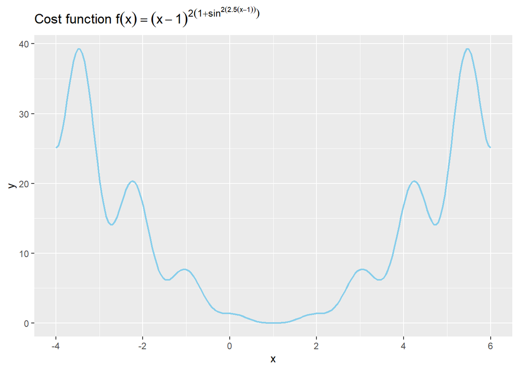

```r
object_func <- function(x) (x-1)^2*(1+sin(2.5*(x-1))^2)
tibble::tibble(x = seq(-4,6, length.out = 200),
               y = object_func(seq(-4,6, length.out = 200))) %>%
  ggplot(aes(x = x, y = y)) +
  geom_line(color = "skyblue", size = 0.75) +
  labs(title = latex2exp::TeX("Cost function $f(x)=(x-1)^2(1+\\sin^2(2.5(x-1)))$")) -> p
print(p)
```

```
##
##  ~ Observed parameter: 1  in 59 iterations.
```

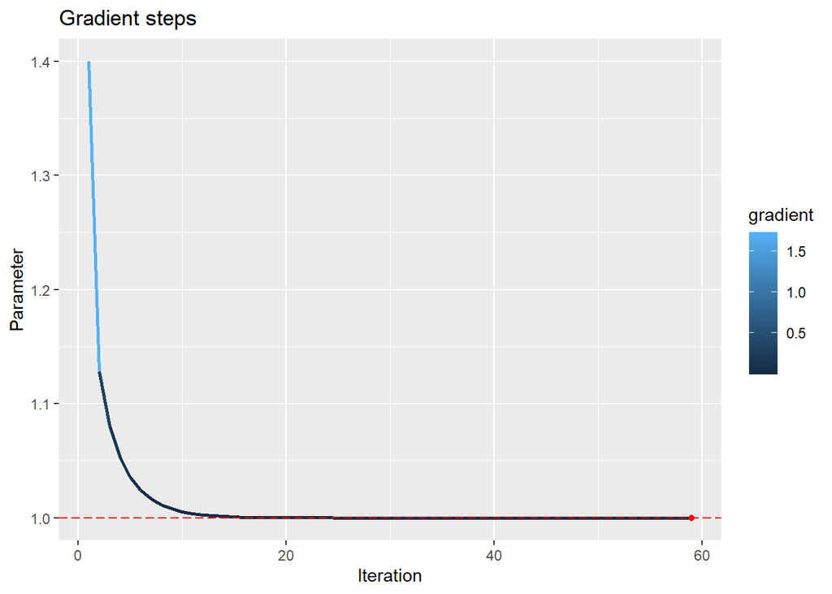

```r
gd <- gradOptimizer(obj_fun = object_func,
                  setParameter = setGradParameter(val_init = 2.4,
                                                rate = 1,
                                                print_step = FALSE,
                                                figure = TRUE))
```

## 3.2 Grid search algorithm

### 3.2.1 Function : `setGridParameter`

- **Argument**:
  - `min_val` : the minimum value of parameter grid.
  - `max_val` : the maximum value of parameter grid.
  - `n_val` : the number of points in the grid.
  - `parameters` : the vector of paramters in case the non-uniform grid is considered.
  - `print_result` : a logical value specifying whether or not to print the observed result.
  - `figure` : a logical value specifying whether or not to plot the graphic of error.
- **Value**:

  This function returns a *list* of all the parameters given in its arguments.

```r
setGridParameter <- function(min_val = 1e-4,
                             max_val = 0.1,
                             n_val = 300,
                             parameters = NULL,
                             print_result = TRUE,
                             figure = TRUE){
  return(list(min_val = min_val,
              max_val = max_val,
              n_val = n_val,
              parameters = parameters,
              print_result = print_result,
              figure = figure))
}
```

### 3.2.2 Function : `gridOptimizer`

- **Argument**:
  - `obj_fun` : the objective function for which its minimizer is to be estimated. It should be a univarate function of real positive variables.
  - `setParameter` : the control of grid search algorithm parameters which should be the function `setGridParameter()` defined above.
- **Value**:

  This function returns a list of the following objects:
  - `opt_param` : the observed value of the minimizer.
  - `opt_error` : the value of optimal risk.
  - `all_risk` : the vector of all the errors evaluated at all the values of considered parameters.
  - `run.time` : the running time of the algorithm.

```r
gridOptimizer <- function(obj_func,
                         setParameter = setGridParameter()){
  t0 <- Sys.time()
  if(is.null(setParameter$parameters)){
    param <- seq(setParameter$min_val,
                 setParameter$max_val,
                 length.out = setParameter$n_val)
  } else{
    param <- setParameter$parameters
  }
  risk <- param %>%
    map_dbl(.f = obj_func)
  id_opt <- which.min(risk)
  opt_ep <- param[id_opt]
  opt_risk <- risk[id_opt]
  if(setParameter$print_result){
    cat("\n* Grid search algorithm...", "\n ~ Observed parameter :", opt_ep)
  }
  if(setParameter$figure){
    tibble(x = param,
           y = risk) %>%
      ggplot(aes(x = x, y = y)) +
      geom_line(color = "skyblue", size = 0.75) +
      geom_point(aes(x = opt_ep, y = opt_risk), color = "red") +
      geom_vline(xintercept = opt_ep, color = "red", linetype = "longdash") +
      labs(title = "Error as function of parameter",
           x = "Parameter",
           y = "Error")-> p
    print(p)
  }
  t1 <- Sys.time()
  return(list(
    opt_param = opt_ep,
    opt_error = opt_risk,
    all_risk = risk,
    run.time = difftime(t1,
                        t0,
                        units = "secs")[[1]])
  )
}
```

> **Example.2**: Again with grid search.

```
##
## * Grid search algorithm...
##  ~ Observed parameter : 1.008016
```

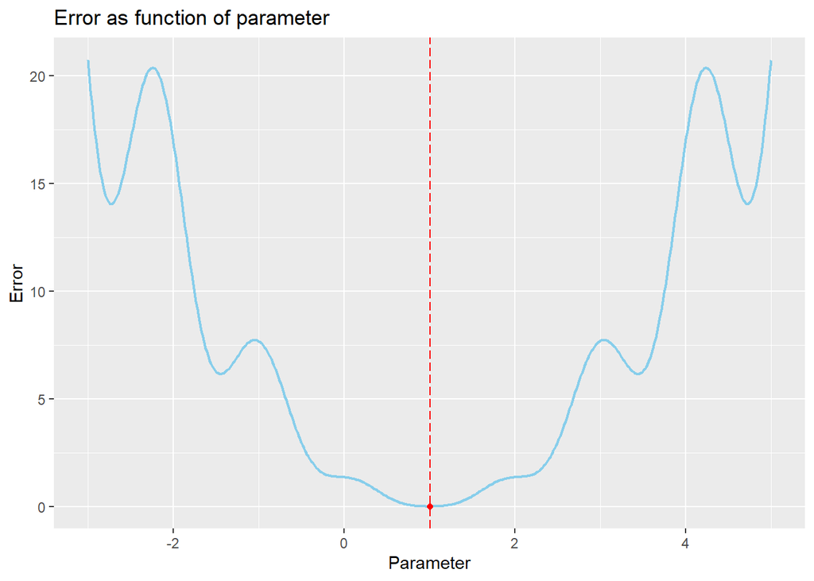

```r
grid <- gridOptimizer(obj_fun = object_func,
                     setParameter = setGridParameter(min_val = -3,
                                                     max_val = 5,
                                                     n_val = 500,
                                                     figure = TRUE))
```

## 3.3 $\kappa$-cross validation lost function

Constructing aggregation method is equivalent to approximating the optimal value of smoothing parameter $h>0$ introduced in section 1.1 by minimizing some lost function. In this study, we propose $\kappa$-fold cross validation lost function defined by

$$\begin{equation}
\label{eq:kappa}
\varphi^{\kappa}(h)=\frac{1}{\kappa}\sum_{k=1}^{\kappa}\sum_{(x_j,y_j)\in
F_k}(g_n({\bf r}(x_j))-y_j)^2
\end{equation}$$
where

- for any $k=1,...,\kappa$, $F_k$ denotes the $k$th validation fold.
- $g_n({\bf r}(x_j))$ is the prediction of $x_j$ of $F_k$, computed using the data points from the remaining part ${\cal D}_{\ell}-F_k$ by,
  $$g_n({\bf
  r}(x_j))=\frac{\sum_{(x_i,y_i)\in{\cal D}_{\ell}-F_k}y_iK_h({\bf
  r}(x_j)- {\bf r}(x_i))}{\sum_{(x_i,y_i)\in{\cal D}_{\ell}-F_k}K_h({\bf
  r}(x_j)- {\bf r}(x_i))}$$

## 3.4 Function: `dist_matrix`

This function computes different distances between data points of each training folds ($\mathcal{D}_{\ell}-F_k$) and the corresponding validation fold $F_k$ for any $k=1,\dots,\kappa$. The distance matrices $D_k=(d[{\bf r}(x_i),{\bf r}(x_j)])_{i,j}$ for $k=1,\dots,\kappa$, where the distance $d$ is defined according to different types kernel functions.

- **Argument**:
  - `basicMachines` : the basic machine object, which is an output of `generateMachines` function.
  - `n_cv` : the number $\kappa$ of cross-validation folds. By default, `n_cv = 5`.
  - `kernel` : the kernel function used for the aggregation, which is an element of {“gaussian”, “epanechnikov”, “biweight”, “triweight”, “triangular”, “naive”}. By default, `kernel = "gaussian"`.
- **Value**:

```r
dist_matrix <- function(basicMachines,
                        n_cv = 5,
                        kernel = "gausian",
                        id_shuffle = NULL){
  n <- nrow(basicMachines$predict2)
  n_each_fold <- floor(n/n_cv)
  # shuffled indices
  if(is.null(id_shuffle)){
    shuffle <- 1:(n_cv-1) %>%
    rep(n_each_fold) %>%
    c(., rep(n_cv, n - n_each_fold * (n_cv - 1))) %>%
    sample
  }else{
    shuffle <- id_shuffle
  }
  # the prediction matrix D_l
  df_ <- as.matrix(basicMachines$predict2)
  if(! (kernel %in% c("naive", "triangular"))){
    pair_dist <- function(M, N){
      n_N <- dim(N)
      n_M <- dim(M)
      res_ <- 1:nrow(N) %>%
        map_dfc(.f = (\(id) tibble('{{id}}' := as.vector(rowSums((M - matrix(rep(N[id,], n_M[1]), ncol = n_M[2], byrow = TRUE))^2)))))
      return(res_)
    }
  }
  if(kernel == "triangular"){
    pair_dist <- function(M, N){
      n_N <- dim(N)
      n_M <- dim(M)
      res_ <- 1:nrow(N) %>%
        map_dfc(.f = (\(id) tibble('{{id}}' := as.vector(rowSums(abs(M - matrix(rep(N[id,], n_M[1]), ncol = n_M[2], byrow = TRUE)))))))
      return(res_)
    }
  }
  if(kernel == "naive"){
    pair_dist <- function(M, N){
      n_N <- dim(N)
      n_M <- dim(M)
      res_ <- 1:nrow(N) %>%
        map_dfc(.f = (\(id) tibble('{{id}}' := as.vector(apply(abs(M - matrix(rep(N[id,], n_M[1]), ncol = n_M[2], byrow = TRUE)), 1, max)))))
      return(res_)
    }
  }
  L <- 1:n_cv %>%
      map(.f = (\(x) pair_dist(df_[shuffle != x,],
                                df_[shuffle == x,])))
  return(list(dist = L,
              id_shuffle = shuffle,
              n_cv = n_cv))
}
```

> **Example.3**: The method `dist_matrix` is implemented on the obtained basic machines built in *Example.1* with the corresponding Gaussian kernel function.

```r
dis <- dist_matrix(basicMachines = basic_machines,
            n_cv = 3,
            kernel = "gaussian")
```

> **Example.4**: From the distance matrix, we can compute the error corresponding to Gaussian kernel function, then use both of the optimization methods to approximate the smoothing paramter in this case.

```
##
##  ~ Observed parameter: 0.01088052  in 55 iterations.
```

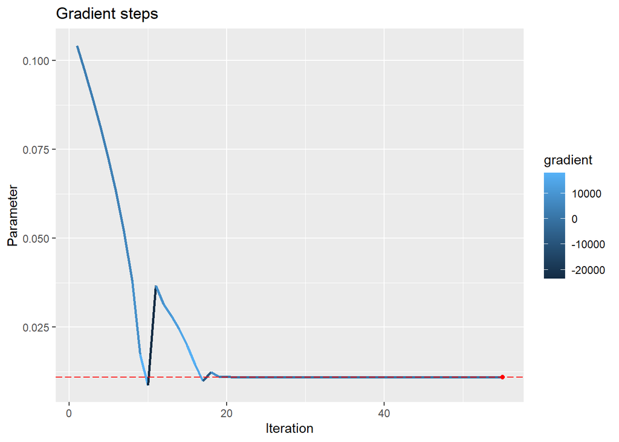

```r
# Gaussian kernel
gaussian_kern <- function(.ep = .05,
                            .dist_matrix,
                            .train_response2,
                            .inv_sigma = sqrt(.5),
                            .alpha = 2){
  kern_fun <- function(x, id, D){
    tem0 <- as.matrix(exp(-(x*D)^(.alpha/2)*.inv_sigma^.alpha))
    y_hat <- .train_response2[.dist_matrix$id_shuffle != id] %*% tem0/colSums(tem0)
    return(sum((y_hat - .train_response2[.dist_matrix$id_shuffle == id])^2))
  }
  temp <- map2(.x = 1:.dist_matrix$n_cv,
                   .y = .dist_matrix$dist,
                   .f = ~ kern_fun(x = .ep, id = .x, D = .y))
  return(Reduce("+", temp))
}

# Kappa cross-validation error
cost_fun <- function(.ep = .05,
                      .dist_matrix,
                      .kernel_func = NULL,
                      .train_response2,
                      .inv_sigma = sqrt(.5)){
  return(.kernel_func(.ep = .ep,
                     .dist_matrix = .dist_matrix,
                     .train_response2 = .train_response2,
                     .inv_sigma = .inv_sigma))
}

# cross_validation
err_cv <- function(x,
                     .dist_matrix = dis,
                     .kernel_func = gaussian_kern,
                     .train_response2 = df[basic_machines$id2, 14]) {
  res <- cost_fun(.ep = x,
              .dist_matrix = .dist_matrix,
              .kernel_func = .kernel_func,
              .train_response2 = .train_response2)
  return(res)
}

# Optimization
opt_param_gd <- gradOptimizer(obj_fun = err_cv,
                              setParameter = setGradParameter(min_val = 0.0001,
                                                              max_val = 1,
                                                              rate = 0.007,
                                                              n_tries = 10,
                                                              print_step = FALSE,
                                                              print_result = TRUE,
                                                              figure = TRUE))
```

```
##
## * Grid search algorithm...
##  ~ Observed parameter : 0.01091082
```

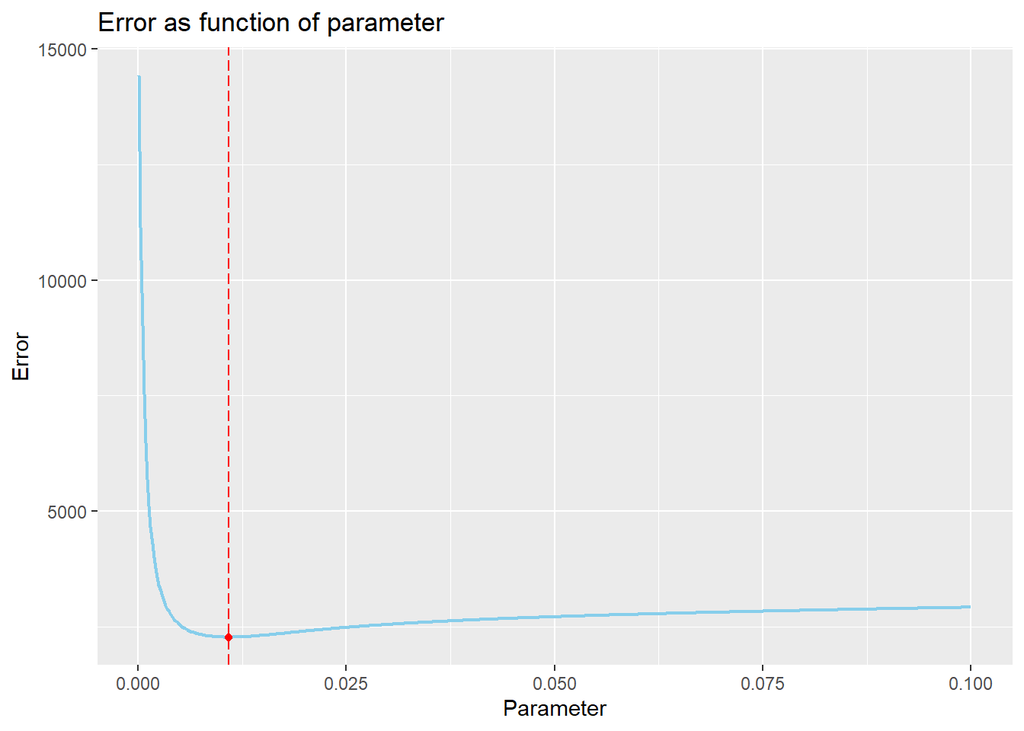

```r
# Optimization
opt_param_grid <- gridOptimizer(obj_fun = err_cv,
                                setParameter = setGridParameter(min_val = 0.0001,
                                                                max_val = 0.1,
                                                                n_val = 500,
                                                                figure = TRUE))
```

```r
cat('* Observed parameter:\n\t - Gradient descent\t:',
    opt_param_gd$opt_param,
    '\t with error:', err_cv(opt_param_gd$opt_param),
    '\n\t - Grid search\t\t:',opt_param_grid$opt_param,
    '\t with error:', err_cv(opt_param_grid$opt_param))
```

```
## * Observed parameter:
##   - Gradient descent : 0.01088052     with error: 2275.178
##   - Grid search      : 0.01091082     with error: 2275.181
```

## 3.5 Fitting parameter

This function gathers the constructed machines and perform an optimization algorithm to approximate the smoothing parameter for the aggregation.

- **Argument**:
  - `train_design` : a matrix or data frame of the training *input data* or the *predictions* given by some predictors.
    - If the *input* data is given, the option `build_machine` must be `TRUE` and all the chosen machines will be constructed using a proportion of the training input (`splits`).
    - If the *predictions* are given, the option `build_machine` must be `FALSE` which indicates that no basic machine is constructed and the paramter is tuned using this predicted features directly.
  - `train_response` : a vector of corresponding response variable of the `train_design`.
  - `scale_input` : a logical value specifying whether or not to scale the input data before building the basic regression predictors. By default, `scale_input = FALSE`.
  - `scale_machine` : a logical value specifying whether or not to scale the predicted features given by all the basic regression predictors, for aggregation. By default, `scale_machine = FALSE`.
  - `build_machine`: a logical value specifying whether or not the basic machines should be constructed. It should be `TRUE` if the `train_design` is the input data, else it should be `FALSE` is the `train_design` is the features of predictions. By default, `build_machine = TRUE`.
  - `machines` : a vector of basic machines to be constructed. It must be a subset of {“lasso”, “ridge”, “knn”, “tree”, “rf”, “xgb”}. By default, `machines = NULL` and all the six types of basic machines are built.
  - `splits` : the proportion of training data used to build the basic machines. By default, `splits = .5`.
  - `n_cv` : the number of cross-validation folds used to tune the smoothing parameter.
  - `inv_sig, alp` : the inverse normalized constant $\sigma^{-1}>0$ and the exponent $\alp>0$ of exponential kernel: $K(x)=e^{-\|x/\sigma\|^{\alpha}}$ for any $x\in\mathbb{R}^d$. By default, `inv_sigma =`$\sqrt{1/2}$ and `alpha = 2` which corresponds to the Gaussian kernel.
  - `kernels` : the kernel function or vector of kernel functions used for the aggregation.
  - `optimizeMethod` : the optimization methods used to learn the smoothing parameter. By default, `optimizeMethod` (“grad”) which stands for gradient descent algorithm, and if “optimizeMethod = grid”, then the grid search algorithm is used. *Note that this should be of the same size as the* `kernels` *argument, otherwise “grid” method will be used for all the kernels*.
  - `setBasicMachineParam` : an option used to set the values of the parameters of the basic machines. `setBasicParameter` function should be fed to this argument.
  - `setGradParam` : an option used to set the values of the parameters of the gradient descent algorithm. `setGradParameter` function should be fed to it.
  - `setGridParam` : an option used to set the values of the parameters of the grid search algorithm. `setGridParameter` function should be fed to it.
- **Value**:

  This function returns a list of the following objects:
  - `opt_parameters` : the observed optimal parameter.
  - `add_parameters` : other aditional parameters such as scaling options, parameters of kernel functions and the optimization methods used.
  - `basic_machines` : the list of basic machine object.
  - `.scale` : the maximum and minimum scaling values of input data.

```r
fit_parameter <- function(train_design,
                          train_response,
                          scale_input = FALSE,
                          scale_machine = FALSE,
                          build_machine = TRUE,
                          machines = NULL,
                          splits = 0.5,
                          n_cv = 5,
                          inv_sigma = sqrt(.5),
                          alp = 2,
                          kernels = "gaussian",
                          optimizeMethod = "grad",
                          setBasicMachineParam = setBasicParameter(),
                          setGradParam = setGradParameter(),
                          setGridParam = setGridParameter()){
  kernels_lookup <- c("gaussian", "epanechnikov", "biweight", "triweight", "triangular", "naive")
  kernel_real <- kernels %>%
    sapply(FUN = function(x) return(match.arg(x, kernels_lookup)))
  if(build_machine){
     mach2 <- generateMachines(train_input = train_design,
                               train_response = train_response,
                               scale_input = scale_input,
                               machines = machines,
                               splits = splits,
                               basicMachineParam = setBasicMachineParam)
  } else{
    mach2 <- list(predict2 = train_design,
                  models = colnames(train_design),
                  id2 = rep(TRUE, nrow(train_design)),
                  train_data = list(train_response = train_response))
  }
  maxs_ <- mins_ <- NULL
  if(scale_machine){
    maxs_ <- map_dbl(.x = mach2$predict2, .f = max)
    mins_ <- map_dbl(.x = mach2$predict2, .f = min)
    mach2$predict2 <- scale(mach2$predict2,
                            center = mins_,
                            scale = maxs_ - mins_)
  }
  # distance matrix to compute loss function
  if_euclid <- FALSE
  id_euclid <- NULL
  n_ker <- length(kernels)
  dist_all <- list()
  id_shuf <- NULL
  for (k_ in 1:n_ker) {
    ker <- kernel_real[k_]
    if(ker == "naive"){
      dist_all[["naive"]] <- dist_matrix(basicMachines = mach2,
                                         n_cv = n_cv,
                                         kernel = "naive",
                                         id_shuffle = id_shuf)
    } else{
      if(ker == "triangular"){
        dist_all[["triangular"]] <- dist_matrix(basicMachines = mach2,
                                                n_cv = n_cv,
                                                kernel = "triangular",
                                                id_shuffle = id_shuf)
      } else{
        if(if_euclid){
          dist_all[[ker]] <- dist_all[[id_euclid]]
        } else{
          dist_all[[ker]] <- dist_matrix(basicMachines = mach2,
                                         n_cv = n_cv,
                                         kernel = ker,
                                         id_shuffle = id_shuf)
          id_euclid <- ker
          if_euclid <- TRUE
        }
      }
    }
    id_shuf <- dist_all[[1]]$id_shuffle
  }

  # Kernel functions
  # ================
  # Gaussian
  gaussian_kernel <- function(.ep = .05,
                              .dist_matrix,
                              .train_response2,
                              .inv_sigma = inv_sigma,
                              .alpha = alp){
  kern_fun <- function(x, id, D){
    tem0 <- as.matrix(exp(- (x*D)^(.alpha/2)*.inv_sigma^.alpha))
    y_hat <- .train_response2[.dist_matrix$id_shuffle != id] %*% tem0/colSums(tem0)
    return(sum((y_hat - .train_response2[.dist_matrix$id_shuffle == id])^2))
  }
  temp <- map2(.x = 1:.dist_matrix$n_cv,
               .y = .dist_matrix$dist,
               .f = ~ kern_fun(x = .ep, id = .x, D = .y))
  return(Reduce("+", temp))
}

# Epanechnikov
  epanechnikov_kernel <- function(.ep = .05,
                                  .dist_matrix,
                                  .train_response2){
  kern_fun <- function(x, id, D){
    tem0 <- as.matrix(1- x*D)
    tem0[tem0 < 0] = 0
    y_hat <- .train_response2[.dist_matrix$id_shuffle != id] %*% tem0/colSums(tem0)
    return(sum((y_hat - .train_response2[.dist_matrix$id_shuffle == id])^2))
  }
  temp <- map2(.x = 1:.dist_matrix$n_cv,
               .y = .dist_matrix$dist,
               .f = ~ kern_fun(x = .ep, id = .x, D = .y))
  return(Reduce("+", temp))
}

# Biweight
  biweight_kernel <- function(.ep = .05,
                              .dist_matrix,
                              .train_response2){
  kern_fun <- function(x, id, D){
    tem0 <- as.matrix(1- x*D)
    tem0[tem0 < 0] = 0
    y_hat <- .train_response2[.dist_matrix$id_shuffle != id] %*% tem0^2/colSums(tem0^2)
    y_hat[is.na(y_hat)] <- 0
    return(sum((y_hat - .train_response2[.dist_matrix$id_shuffle == id])^2))
  }
  temp <- map2(.x = 1:.dist_matrix$n_cv,
                   .y = .dist_matrix$dist,
                   .f = ~ kern_fun(x = .ep, id = .x, D = .y))
  return(Reduce("+", temp))
}

# Triweight
  triweight_kernel <- function(.ep = .05,
                               .dist_matrix,
                               .train_response2){
  kern_fun <- function(x, id, D){
    tem0 <- as.matrix(1- x*D)
    tem0[tem0 < 0] = 0
    y_hat <- .train_response2[.dist_matrix$id_shuffle != id] %*% tem0^3/colSums(tem0^3)
    y_hat[is.na(y_hat)] <- 0
    return(sum((y_hat - .train_response2[.dist_matrix$id_shuffle == id])^2))
  }
  temp <- map2(.x = 1:.dist_matrix$n_cv,
                   .y = .dist_matrix$dist,
                   .f = ~ kern_fun(x = .ep, id = .x, D = .y))
  return(Reduce("+", temp))
}

# Triangular
  triangular_kernel <- function(.ep = .05,
                                .dist_matrix,
                                .train_response2){
  kern_fun <- function(x, id, D){
    tem0 <- as.matrix(1- x*D)
    tem0[tem0 < 0] <- 0
    y_hat <- .train_response2[.dist_matrix$id_shuffle != id] %*% tem0/colSums(tem0)
    y_hat[is.na(y_hat)] = 0
    return(sum((y_hat - .train_response2[.dist_matrix$id_shuffle == id])^2))
  }
  temp <- map2(.x = 1:.dist_matrix$n_cv,
                   .y = .dist_matrix$dist,
                   .f = ~ kern_fun(x = .ep, id = .x, D = .y))
  return(Reduce("+", temp))
  }

  # Naive
  naive_kernel <- function(.ep = .05,
                                .dist_matrix,
                                .train_response2){
    kern_fun <- function(x, id, D){
      tem0 <- (as.matrix(x*D) < 1)
      y_hat <- .train_response2[.dist_matrix$id_shuffle != id] %*% tem0/colSums(tem0)
      y_hat[is.na(y_hat)] = 0
      return(sum((y_hat - .train_response2[.dist_matrix$id_shuffle == id])^2))
    }
    temp <- map2(.x = 1:.dist_matrix$n_cv,
                 .y = .dist_matrix$dist,
                 .f = ~ kern_fun(x = .ep, id = .x, D = .y))
    return(Reduce("+", temp))
  }

  # error function
  error_cv <- function(x,
                       .dist_matrix = NULL,
                       .kernel_func = NULL,
                       .train_response2 = NULL){
    res <- .kernel_func(.ep = x,
                        .dist_matrix = .dist_matrix,
                        .train_response2 = .train_response2)
    return(res/n_cv)
  }

  # list of kernel functions
  list_funs <- list(gaussian = gaussian_kernel,
                    epanechnikov = epanechnikov_kernel,
                    biweight = biweight_kernel,
                    triweight = triweight_kernel,
                    triangular = triangular_kernel,
                    naive = naive_kernel)

  # error for all kernel functions
  error_func <- kernel_real %>%
    map(.f = ~ (\(x) error_cv(x,
                              .dist_matrix = dist_all[[.x]],
                              .kernel_func = list_funs[[.x]],
                              .train_response2 = train_response[mach2$id2])))
  names(error_func) <- kernels
  # list of prameter setup
  list_param <- list(grad = setGradParam,
                     GD = setGradParam,
                     grid = setGridParam)
  # list of optimizer
  list_optimizer <- list(grad = gradOptimizer,
                         GD = gradOptimizer,
                         grid = gridOptimizer)
  optMethods <- optimizeMethod
  if(length(kernels) != length(optMethods)){
    warning("* kernels and optimization methods differ in sides! Grid search will be used!")
    optMethods = rep("grid", length(kernels))
  }

  # Optimization
  parameters <- map2(.x = kernels,
                     .y = optMethods,
                     .f = ~ list_optimizer[[.y]](obj_fun = error_func[[.x]],
                                                 setParameter = list_param[[.y]]))
  names(parameters) <- paste0(kernel_real, "_", optMethods)
  return(list(opt_parameters = parameters,
              add_parameters = list(scale_input = scale_input,
                                    scale_machine = scale_machine,
                                    inv_sigma = inv_sigma,
                                    alp = alp,
                                    opt_methods = optimizeMethod),
              basic_machines = mach2,
              .scale = list(min = mins_,
                            max = maxs_)))
}
```

> **Example.5**: We approximate the smoothing parameter of `Boston` data.

```r
df <- MASS::Boston
train <- logical(nrow(df))
train[sample(length(train), floor(0.75*nrow(df)))] <- TRUE

param <- fit_parameter(train_design = df[train, 1:13],
                       train_response = df[train, 14],
                       machines = c("knn", "rf", "xgb"),
                       splits = .65,
                       n_cv = 3,
                       kernels = c("gaussian", "gaussian", "biweight", "triangular"),
                       optimizeMethod = c("grad", "grid", "grid", "grid"),
                       setBasicMachineParam = setBasicParameter(k = 2:6,
                                                                ntree = 1:5*100,
                                                                nrounds_xgb = 1:5*100),
                       setGradParam = setGradParameter(rate = 0.001))
```

```
##
## * Building basic machines ...
##  ~ Progress: ... 33% ... 67% ... 100%
## * Gradient descent algorithm ...
##   Step   |  Parameter    |  Gradient |  Threshold
##  ---------------------------------------------------
##    0     |  0.011200     |  843.937311   |  1e-10
##  ---------------------------------------------------
##    1     |  0.010200     |  -7.78907e+02     |  843.9373
##    2     |  0.0111229    |  736.969484   |  778.9071
##    3     |  0.0102497    |  -6.84751e+02     |  736.9695
##    4     |  0.0110611    |  649.135494   |  684.7506
##    5     |  0.0102919    |  -6.0604e+02  |  649.1355
##    6     |  0.011010     |  575.313433   |  606.0402
##    7     |  0.0103283    |  -5.3904e+02  |  575.3134
```

[output cut: 92 more lines]

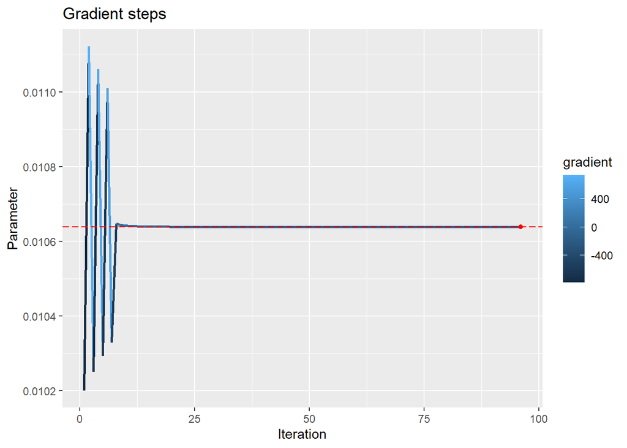

```
##
## * Grid search algorithm...
##  ~ Observed parameter : 0.01079164
```

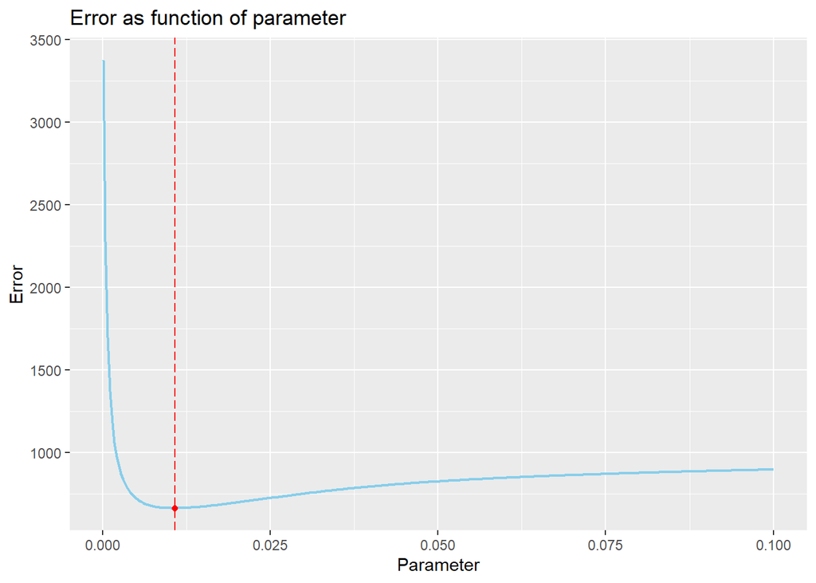

```
##
## * Grid search algorithm...
##  ~ Observed parameter : 0.001102341
```

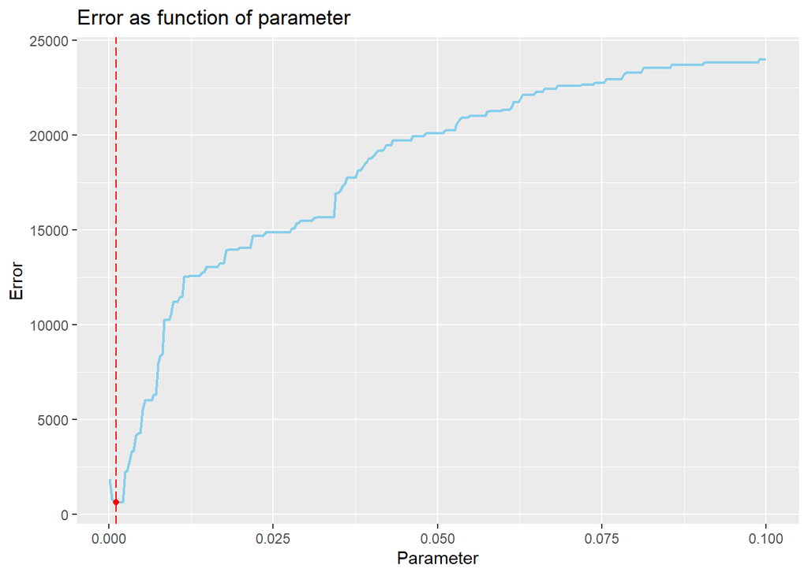

```
##
## * Grid search algorithm...
##  ~ Observed parameter : 0.01145987
```

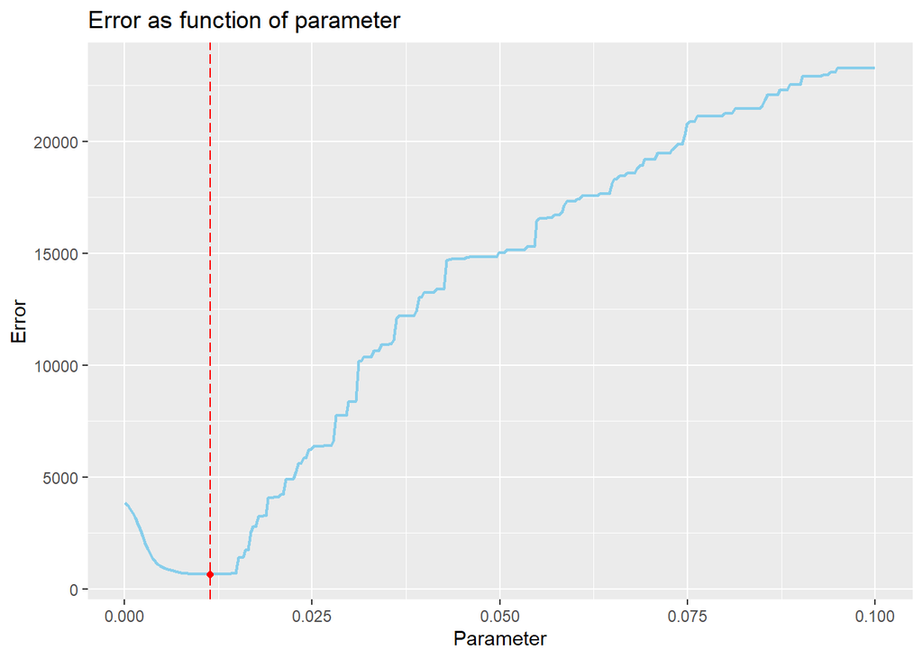

```r
param$opt_parameters %>%
  map_dfc(.f = ~ .x$opt_param) %>%
  print
```

```
## # A tibble: 1 × 4
##   gaussian_grad gaussian_grid biweight_grid triangular_grid
##           <dbl>         <dbl>         <dbl>           <dbl>
## 1        0.0106        0.0108       0.00110          0.0115
```

# 4 Prediction

The smoothing parameter obtained from the previous section can be used to make the final predictions.

## 4.1 Kernel functions

Several types of kernel functions used for the aggregation are defined in this section.

- **Argument**:
  - `epsilon` : the value of the parameter used.
  - `.y2` : the vector of response variable of the second part $\mathcal{D}_{\ell}$ of the training data, which is used for the aggregation.
  - `.distance` : the distance matrix object obtained from `dist_matrix` function.
  - `.kern` : the string specifying the kernel function. By default, `.kern = "gaussian"`.
  - `.inv_sig, .alp` : the parameters of exponential kernel function.
  - `.meth` : the string of optimization methods to be linked to the name of the kernel functions if one kernel is used more than once.
- **Value**:

  This function returns the predictions of the aggregation method evaluated with the given parameter.

```r
kernel_pred <- function(epsilon,
                        .y2,
                        .distance,
                        .kern = "gaussian",
                        .inv_sig = sqrt(.5),
                        .alp = 2,
                        .meth = NA){
  dis <- as.matrix(.distance)
  # Kernel functions
  # ================
  gaussian_kernel <- function(.ep,
                              .inv_sigma = .inv_sig,
                              .alpha = .alp){
    tem0 <- exp(- (.ep*dis)^(.alpha/2)*.inv_sig^.alpha)
    y_hat <- .y2 %*% tem0/colSums(tem0)
    return(t(y_hat))
  }

  # Epanechnikov
  epanechnikov_kernel <- function(.ep){
    tem0 <- 1- .ep*dis
    tem0[tem0 < 0] = 0
    y_hat <- .y2 %*% tem0/colSums(tem0)
    return(t(y_hat))
  }
  # Biweight
  biweight_kernel <- function(.ep){
    tem0 <- 1- .ep*dis
    tem0[tem0 < 0] = 0
    y_hat <- .y2 %*% tem0^2/colSums(tem0^2)
    y_hat[is.na(y_hat)] <- 0
    return(t(y_hat))
  }

  # Triweight
  triweight_kernel <- function(.ep){
    tem0 <- 1- .ep*dis
    tem0[tem0 < 0] = 0
    y_hat <- .y2 %*% tem0^3/colSums(tem0^3)
    y_hat[is.na(y_hat)] <- 0
    return(t(y_hat))
  }

  # Triangular
  triangular_kernel <- function(.ep){
    tem0 <- 1- .ep*dis
    tem0[tem0 < 0] <- 0
    y_hat <- .y2 %*% tem0/colSums(tem0)
    y_hat[is.na(y_hat)] = 0
    return(t(y_hat))
 }
  # Naive
  naive_kernel <- function(.ep){
      tem0 <- (.ep*dis < 1)
      y_hat <- .y2 %*% tem0/colSums(tem0)
      y_hat[is.na(y_hat)] = 0
      return(t(y_hat))
  }
  # Prediction
  kernel_list <- list(gaussian = gaussian_kernel,
                      epanechnikov = epanechnikov_kernel,
                      biweight = biweight_kernel,
                      triweight = triweight_kernel,
                      triangular = triangular_kernel,
                      naive = naive_kernel)
  res <- tibble(as.vector(kernel_list[[.kern]](.ep = epsilon)))
  names(res) <- ifelse(is.na(.meth),
                       .kern,
                       paste0(.kern, '_', .meth))
  return(res)
}
```

## 4.2 Functions: `predict_agg`

- **Argument**:
  - `fitted_models` : the object obtained from `fit_parameter` function.
  - `new_data` : the new testing data to be predicted.
  - `test_response` : the testing response variable, it is optional. If it is given, the mean square error on the testing data is also computed. By default, `test_response = NULL`.
- **Value**:

  This function returns a *list* of the following objects:
  - `fitted_aggregate` : the predictions by the aggregation methods.
  - `fitted_machine` : the predictions given by all the basic machines.
  - `mse` : the mean square error computed only if the `test_reponse` argument is note `NULL`.

```r
# Prediction
predict_agg <- function(fitted_models,
                        new_data,
                        test_response = NULL){
  opt_param <- fitted_models$opt_parameters
  add_param <- fitted_models$add_parameters
  basic_mach <- fitted_models$basic_machines
  kern0 <- names(opt_param)
  kernel0 <- stringr::str_split(kern0, "_") %>%
    imap_dfc(.f = ~ tibble("{.y}" := .x))
  kerns <- kernel0[1,] %>%
    as.character
  opt_meths <- kernel0[2,] %>%
    as.character
  new_data_ <- new_data
  # if basic machines are built
  if(is.list(basic_mach$models)){
    mat_input <- as.matrix(basic_mach$train_data$train_input)
    if(add_param$scale_input){
      new_data_ <- scale(new_data,
                         center = basic_mach$scale_min,
                         scale = basic_mach$scale_max - basic_mach$scale_min)
    }
    if(is.matrix(new_data_)){
      mat_test <- new_data_
      df_test <- as_tibble(new_data_)
    } else {
      mat_test <- as.matrix(new_data_)
      df_test <- new_data_
    }

    # Prediction test by basic machines
    built_models <- basic_mach$models
    pred_test <- function(meth){
      if(meth == "knn"){
        pre <- 1:length(built_models[[meth]]) %>%
          map_dfc(.f = (\(k) tibble('{{k}}' := FNN::knn.reg(train = mat_input[!basic_mach$id2,],
                                                            test = mat_test,
                                                            y = basic_mach$train_data$train_response[!basic_mach$id2],
                                                            k = built_models[[meth]][[k]])$pred)))
      }
      if(meth %in% c("tree", "rf")){
        pre <- 1:length(built_models[[meth]]) %>%
          map_dfc(.f = (\(k) tibble('{{k}}' := as.vector(predict(built_models[[meth]][[k]], df_test)))))
      }
      if(meth %in% c("lasso", "ridge")){
        pre <- 1:length(built_models[[meth]]) %>%
          map_dfc(.f = (\(k) tibble('{{k}}' := as.vector(predict.glmnet(built_models[[meth]][[k]], mat_test)))))
      }
      if(meth == "xgb"){
        pre <- 1:length(built_models[[meth]]) %>%
          map_dfc(.f = (\(k) tibble('{{k}}' := as.vector(predict(built_models[[meth]][[k]], mat_test)))))
      }
      colnames(pre) <- names(built_models[[meth]])
      return(pre)
    }
    pred_test_all <- names(built_models) %>%
      map_dfc(.f = pred_test)
  } else{
    pred_test_all <- new_data_
  }
  pred_test0 <- pred_test_all
  if(add_param$scale_machine){
      pred_test_all <- scale(pred_test_all,
                             center = fitted_models$.scale$min,
                             scale = fitted_models$.scale$max - fitted_models$.scale$min)
  }
  # Prediction train2
  pred_train_all <- basic_mach$predict2
  colnames(pred_test_all) <- colnames(pred_train_all)
  d_train <- dim(pred_train_all)
  d_test <- dim(pred_test_all)
  pred_test_mat <- as.matrix(pred_test_all)
  pred_train_mat <- as.matrix(pred_train_all)
  # Distance matrix
  dist_mat <- function(kernel = "gausian"){
    if(!(kernel %in% c("naive", "triangular"))){
      res_ <- 1:d_test[1] %>%
        map_dfc(.f = (\(id) tibble('{{id}}' := as.vector(rowSums((pred_train_mat - matrix(rep(pred_test_mat[id,],
                                                                                              d_train[1]),
                                                                                          ncol = d_train[2],
                                                                                          byrow = TRUE))^2)))))
    }
    if(kernel == "triangular"){
      res_ <- 1:d_test[1] %>%
        map_dfc(.f = (\(id) tibble('{{id}}' := as.vector(rowSums(abs(pred_train_mat - matrix(rep(pred_test_mat[id,],
                                                                                                 d_train[1]),
                                                                                             ncol = d_train[2],
                                                                                             byrow = TRUE)))))))
    }
    if(kernel == "naive"){
      res_ <- 1:d_test[1] %>%
        map_dfc(.f = (\(id) tibble('{{id}}' := as.vector(apply(abs(pred_train_mat - matrix(rep(pred_test_mat[id,], d_train[1]),
                                                                                           ncol = d_train[2],
                                                                                           byrow = TRUE)), 1, max)))))
    }
    return(res_)
  }
  dists <- 1:length(kerns) %>%
      map(.f = ~ dist_mat(kerns[.x]))
  tab_nam <- table(kerns)
  nam <- names(tab_nam[tab_nam > 1])
  vec <- rep(NA, length(kerns))
  for(id in nam){
    id_ <- kerns == id
    if(!is.null(id_)){
      vec[id_] = add_param$opt_methods[id_]
    }
  }
  prediction <- 1:length(kerns) %>%
    map_dfc(.f = ~ kernel_pred(epsilon = opt_param[[kern0[.x]]]$opt_param,
                               .y2 = basic_mach$train_data$train_response[basic_mach$id2],
                               .distance = dists[[.x]],
                               .kern = kerns[.x],
                               .inv_sig = add_param$inv_sigma,
                               .alp = add_param$alp,
                               .meth = vec[.x]))
  if(is.null(test_response)){
    return(list(fitted_aggregate = prediction,
           fitted_machine = pred_test_all))
  } else{
    error <- cbind(pred_test_all, prediction) %>%
      dplyr::mutate(y_test = test_response) %>%
      dplyr::summarise_all(.funs = ~ (. - y_test)) %>%
      dplyr::select(-y_test) %>%
      dplyr::summarise_all(.funs = ~ mean(.^2))
    return(list(fitted_aggregate = prediction,
                fitted_machine = pred_test0,
                mse = error))
  }
}
```

> **Example.6** Aggregation on `Boston` dataset.

```r
pred <- predict_agg(param,
            new_data = df[!train, -14],
            test_response = df[!train, 14])
sqrt(pred$mse)
```

| knn1 | knn2 | knn3 | knn4 | knn5 | rf1 | rf2 | rf3 | rf4 | rf5 | xgb1 | xgb2 | xgb3 | xgb4 | xgb5 | gaussian_grad | gaussian_grid | biweight | triangular |
| --- | --- | --- | --- | --- | --- | --- | --- | --- | --- | --- | --- | --- | --- | --- | --- | --- | --- | --- |
| 6.936989 | 6.949509 | 6.999177 | 7.01963 | 6.947789 | 3.709755 | 3.566909 | 3.555333 | 3.501455 | 3.587264 | 4.487216 | 4.487697 | 4.487697 | 4.487697 | 4.487697 | 3.871688 | 3.872603 | 3.900232 | 3.855961 |

# 5 Function : `kernelAggReg`

This function puts together all the functions above and provides the desire result of the kernel-based consensual aggregation method.

  This function return a *list* of the following objects:
  - `fitted_aggregate` : the predictions of the testing data given by the aggregation methods correpsonding to all the kernel functions.
  - `fitted_machine` : the predictions of the testing data given by the basic machines.
  - `pred_train2` : the predictions of the second part of the training data $\mathcal{D}_{\ell}$ by all the basic machines.
  - `opt_parameter` : the observed optimal smoothing parameters.
  - `mse` : the mean square error evaluated on the testing data if the testing response variable is given.
  - `kernels` : the kernel functions used.

```r
kernelAggReg <- function(train_design,
                          train_response,
                          test_design,
                          test_response = NULL,
                          scale_input = FALSE,
                          scale_machine = FALSE,
                          build_machine = TRUE,
                          machines = NULL,
                          splits = 0.5,
                          n_cv = 5,
                          inv_sigma = sqrt(.5),
                          alp = 2,
                          kernels = "gaussian",
                          optimizeMethod = "grad",
                          setBasicMachineParam = setBasicParameter(),
                          setGradParam = setGradParameter(),
                          setGridParam = setGridParameter()){
  # build machines + tune parameter
  fit_mod <- fit_parameter(train_design = train_design,
                           train_response = train_response,
                           scale_input = scale_input,
                           scale_machine = scale_machine,
                           build_machine = build_machine,
                           machines = machines,
                           splits = splits,
                           n_cv = n_cv,
                           inv_sigma = inv_sigma,
                           alp = alp,
                           kernels = kernels,
                           optimizeMethod = optimizeMethod,
                           setBasicMachineParam = setBasicMachineParam,
                           setGradParam = setGradParam,
                           setGridParam = setGridParam)
  # prediction
  pred <- predict_agg(fitted_models = fit_mod,
                      new_data = test_design,
                      test_response = test_response)
  return(list(fitted_aggregate = pred$fitted_aggregate,
              fitted_machine = pred$fitted_machine,
              pred_train2 = fit_mod$basic_machines$predict2,
              opt_parameter = fit_mod$opt_parameters,
              mse = pred$mse,
              kernels = kernels,
              ind_D2 = fit_mod$basic_machines$id2))
}
```

> **Example.7** Complete aggregation on `Boston` dataset.

```r
train <- logical(nrow(df))
train[sample(length(train), floor(0.75*nrow(df)))] <- TRUE

agg <- kernelAggReg(train_design = df[train, 1:13],
                    train_response = df[train, 14],
                    test_design = df[!train,1:13],
                    test_response = df[!train, 14],
                    machines = c("knn", "rf", "xgb"),
                    splits = .5,
                    n_cv = 3,
                    kernels = c("gaussian", "gaussian", "biweight", "triangular"),
                    optimizeMethod = c("grad", "grid", "grid", "grid"),
                    setBasicMachineParam = setBasicParameter(k = 2:5,
                                                             ntree = 2:4*100,
                                                             nrounds_xgb = 3:5*100),
                    setGradParam = setGradParameter(rate = 0.001))
```

```
##
## * Building basic machines ...
##  ~ Progress: ... 33% ... 67% ... 100%
## * Gradient descent algorithm ...
##   Step   |  Parameter    |  Gradient |  Threshold
##  ---------------------------------------------------
##    0     |  0.088900     |  8.354137     |  1e-10
##  ---------------------------------------------------
##    1     |  0.087900     |  -1.12669e+01     |  8.354137
##    2     |  0.0892487    |  15.029277    |  11.26695
##    3     |  0.0874496    |  -2.03374e+01     |  15.02928
##    4     |  0.0898841    |  26.976214    |  20.33738
##    5     |  0.086655     |  -3.67033e+01     |  26.97621
##    6     |  0.0910484    |  48.152853    |  36.70329
##    7     |  0.0852844    |  -6.6032e+01  |  48.15285
```

[output cut: 60 more lines]

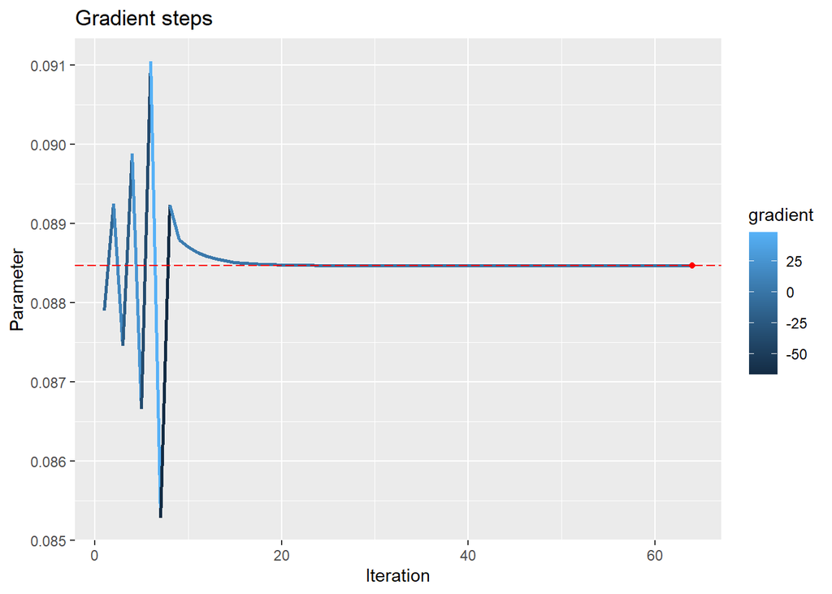

```
##
## * Grid search algorithm...
##  ~ Observed parameter : 0.08830602
```

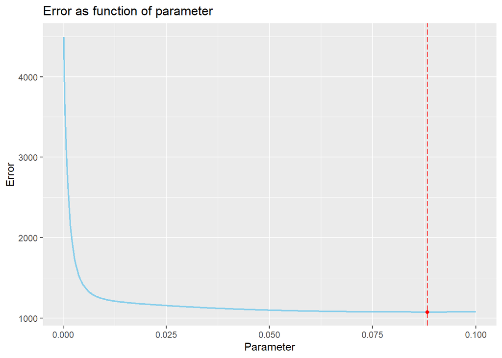

```
##
## * Grid search algorithm...
##  ~ Observed parameter : 0.00277291
```

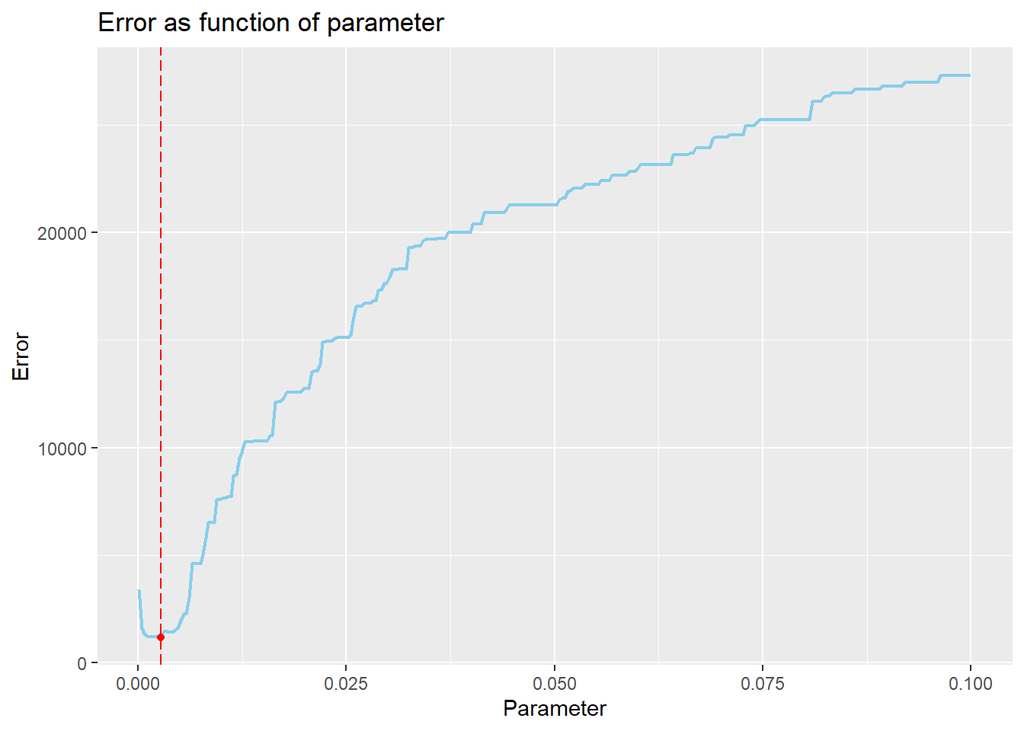

```
##
## * Grid search algorithm...
##  ~ Observed parameter : 0.01546923
```

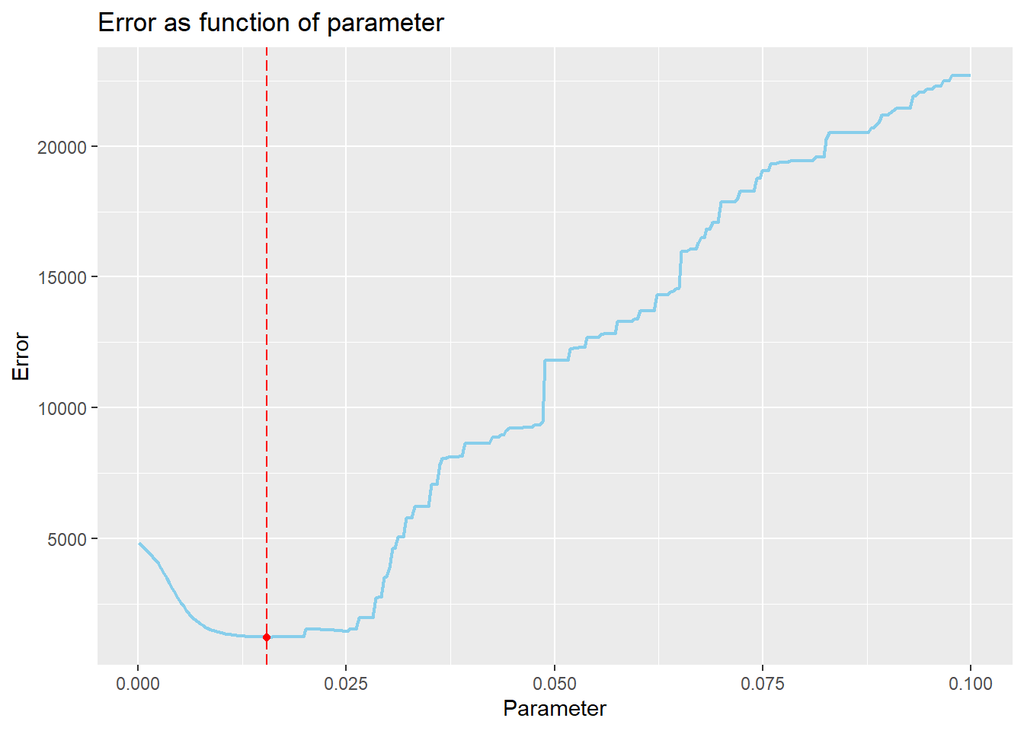

```r
sqrt(agg$mse)
```

| knn1 | knn2 | knn3 | knn4 | rf1 | rf2 | rf3 | xgb1 | xgb2 | xgb3 | gaussian_grad | gaussian_grid | biweight | triangular |
| --- | --- | --- | --- | --- | --- | --- | --- | --- | --- | --- | --- | --- | --- |
| 8.054887 | 8.419201 | 8.320067 | 8.587267 | 5.203948 | 5.147664 | 5.104936 | 5.993274 | 5.993274 | 5.993274 | 4.919485 | 4.919295 | 4.970704 | 5.103977 |